# Biostatistics HW5

吴嘉骜 21307130203

2024-5-26

## Endocrinology (Problems 12.31-12.34)

### Problem 12.31

An ANOVA test can be used to compare the mean rate of bone loss in the three groups.

### Problem 12.32

```r
# Given data
bone_loss_means <- c(-0.43, -2.62, -3.98)
group_labels <- c("Estrogen", "Calcium", "Placebo")
n <- c(15, 15, 13)
sd <- c(1.60, 2.68, 1.63)

# Calculate the Overall Mean
overall_mean <- sum(bone_loss_means * n) / sum(n)
cat("Overall Mean:", overall_mean, "\n")
```

```
## Overall Mean: -2.267209
```

```r
# Calculate the Sum of Squares Between (SSB)
ssb <- sum(n * (bone_loss_means - overall_mean)^2)
cat("Sum of Squares Between (SSB):", ssb, "\n")
```

```
## Sum of Squares Between (SSB): 90.63447
```

```r
# Calculate the Sum of Squares Within (SSW)
ssw <- sum((n - 1) * (sd^2))
cat("Sum of Squares Within (SSW):", ssw, "\n")
```

```
## Sum of Squares Within (SSW): 168.2764
```

```r
# Degrees of Freedom
df_between <- length(bone_loss_means) - 1
df_within <- sum(n) - length(bone_loss_means)
cat("Degrees of Freedom Between (df_between):", df_between, "\n")
```

```
## Degrees of Freedom Between (df_between): 2
```

```r
cat("Degrees of Freedom Within (df_within):", df_within, "\n")
```

```
## Degrees of Freedom Within (df_within): 40
```

```r
# Calculate the Mean Squares
msb <- ssb / df_between
msw <- ssw / df_within
cat("Mean Square Between (MSB):", msb, "\n")
```

```
## Mean Square Between (MSB): 45.31723
```

```r
cat("Mean Square Within (MSW):", msw, "\n")
```

```
## Mean Square Within (MSW): 4.20691
```

```r
# Calculate the F-statistic
f_statistic <- msb / msw
cat("F-statistic:", f_statistic, "\n")
```

```
## F-statistic: 10.77209
```

```r
# P-value from F-distribution
p_value <- pf(f_statistic, df_between, df_within, lower.tail = FALSE)
cat("P-value:", p_value, "\n")
```

```
## P-value: 0.0001809084
```

The p-value is 0.0002, indicating a very significant difference in the mean rate of bone loss among the three groups.

### Problem 12.33

```r
means <- c(-0.43, -2.62, -3.98)
sds <- c(1.60, 2.68, 1.63)
n <- c(15, 15, 13)
labels <- c("Estrogen", "Calcium", "Placebo")

# Function to calculate t-statistic and p-value
t_test_manual <- function(mean1, mean2, sd1, sd2, n1, n2) {
  sp <- sqrt(((n1 - 1) * sd1^2 + (n2 - 1) * sd2^2) / (n1 + n2 - 2))
  t_stat <- (mean1 - mean2) / (sp * sqrt(1/n1 + 1/n2))
  df <- n1 + n2 - 2
  p_value <- 2 * pt(-abs(t_stat), df)
  return(p_value)
}

# Pairwise comparisons
p_value_estrogen_calcium <- t_test_manual(means[1], means[2], sds[1], sds[2], n[1], n[2])
p_value_estrogen_placebo <- t_test_manual(means[1], means[3], sds[1], sds[3], n[1], n[3])
p_value_calcium_placebo <- t_test_manual(means[2], means[3], sds[2], sds[3], n[2], n[3])

# Combine p-values
p_values <- c(p_value_estrogen_calcium, p_value_estrogen_placebo, p_value_calcium_placebo)
names(p_values) <- c("Estrogen vs Calcium", "Estrogen vs Placebo", "Calcium vs Placebo")

# Apply Bonferroni correction
# p_values_corrected <- p.adjust(p_values, method = "bonferroni")
num_comparisons <- length(p_values)
adjusted_p_values <- p_values * num_comparisons

# Print results
cat("Pairwise p-values of t tests:\n", p_values, "\n\n")
```

```
## Pairwise p-values of t tests:
##  0.01115692 4.07935e-06 0.1238701
```

```r
cat("Pairwise p-values of multiple comparisons:\n", adjusted_p_values, "\n")
```

```
## Pairwise p-values of multiple comparisons:
##  0.03347077 1.223805e-05 0.3716102
```

### Problem 12.34

Using the Bonferroni correction is more appropriate for pairwise comparisons after conducting an ANOVA test. This is because it controls the family-wise error rate, ensuring that the probability of making one or more type I errors across all comparisons remains at the desired significance level.

## Gastroenterology (Problems 12.42-12.43)

### Problem 12.42

For comparing three groups without assuming normality, we can use the Kruskal-Wallis test, which is a non-parametric method.

### Problem 12.43

We first perform the Kruskal-Wallis test.

```r
df <- read.csv("tab12-39.csv")
kruskal_test <- kruskal.test(ProtConc ~ Trypsin, data = df)
kruskal_test
```

```
##
##  Kruskal-Wallis rank sum test
##
## data:  ProtConc by Trypsin
## Kruskal-Wallis chi-squared = 2.8618, df = 2, p-value = 0.2391
```

The p-value is 0.239, which is greater than 0.05. This indicates that there is no statistically significant difference in protein concentration among the three groups.

We then perform ANOVA.

```r
anova_model <- aov(ProtConc ~ Trypsin, data = df)
summary(anova_model)
```

```
##             Df Sum Sq Mean Sq F value Pr(>F)
## Trypsin      1   18.2  18.201   2.422  0.132
## Residuals   26  195.4   7.516
```

The ANOVA p-value is 0.132, also greater than 0.05, but lesser than the Kruskal-Wallis p-value.

## Pulmonary Disease (Problems 12.6-12.8)

### Problem 12.6

```r
df <- read.csv("tab12-30.csv")
# group_A <- df$BronReact[df$LungGroup == "A"]
# group_B <- df$BronReact[df$LungGroup == "B"]
# group_C <- df$BronReact[df$LungGroup == "C"]
anova_model <- aov(BronReact ~ LungGroup, data = df)
summary(anova_model)
```

```
##             Df Sum Sq Mean Sq F value Pr(>F)
## LungGroup    2  503.5  251.77   4.989 0.0181 *
## Residuals   19  958.8   50.46
## ---
## Signif. codes:  0 '***' 0.001 '**' 0.01 '*' 0.05 '.' 0.1 ' ' 1
```

From the ANOVA results, the p-value is 0.0181, less than 0.05. This indicates that there is a statistically significant overall mean difference in bronchial reactivity among the three lung-function groups.

### Problem 12.7

```r
library(agricolae)
LSD_test <- LSD.test(anova_model, "LungGroup", p.adj = "none")
print(LSD_test)
```

```
## $statistics
##    MSerror Df     Mean      CV
##   50.46329 19 10.16364 69.8938
##
## $parameters
##         test p.ajusted    name.t ntr alpha
##   Fisher-LSD      none LungGroup   3  0.05
##
## $means
##   BronReact       std  r       se       LCL      UCL Min  Max   Q25  Q50    Q75
## A    18.680 10.065635  5 3.176894 12.030684 25.32932 4.1 30.0 13.80 20.8 24.700
## B     8.575  6.837347 12 2.050677  4.282885 12.86712 2.2 28.1  4.65  7.5 10.075
## C     5.460  3.134167  5 3.176894 -1.189316 12.10932 2.0  9.2  2.50  6.1  7.500
##
## $comparison
## NULL
##
## $groups
##   BronReact groups
## A    18.680      a
## B     8.575      b
## C     5.460      b
##
## attr(,"class")
## [1] "group"
```

The LSD test indicates that the mean bronchial reactivity of Group A is significantly different from Groups B and C. Groups B and C are not significantly different from each other.

### Problem 12.8

```r
bonferroni_test <- pairwise.t.test(df$BronReact, df$LungGroup, p.adjust.method = "bonferroni")
print(bonferroni_test)
```

```
##
##  Pairwise comparisons using t tests with pooled SD
##
## data:  df$BronReact and df$LungGroup
##
##   A     B
## B 0.045 -
## C 0.025 1.000
##
## P value adjustment method: bonferroni
```

The Bonferroni test confirms that Group A is significantly different from Groups B and C. However, Groups B and C are not significantly different from each other.

## Hematology (Problems 11.1-11.7)

### Problem 11.1

```r
df <- read.csv("tab11-17.csv")
reticulocytes <- df$Ret_Per
lymphocytes <- df$Lymph_Num
model <- lm(lymphocytes ~ reticulocytes)
summary(model)
```

```
##
## Call:
## lm(formula = lymphocytes ~ reticulocytes)
##
## Residuals:
##      Min       1Q   Median       3Q      Max
## -1218.82  -128.47    67.84   168.76   958.95
##
## Coefficients:
##               Estimate Std. Error t value Pr(>|t|)
## (Intercept)     1894.8      348.5   5.437 0.000969 ***
## reticulocytes    112.1      184.7   0.607 0.563109
## ---
## Signif. codes:  0 '***' 0.001 '**' 0.01 '*' 0.05 '.' 0.1 ' ' 1
##
## Residual standard error: 700.6 on 7 degrees of freedom
## Multiple R-squared:  0.04998,    Adjusted R-squared:  -0.08574
## F-statistic: 0.3683 on 1 and 7 DF,  p-value: 0.5631
```

From the result above, the regression line is $y = 1894.8 + 112.1x$, where $y$ is the number of lymphocytes and $x$ is the percentage of reticulocytes.

### Problem 11.2

From the p-value of the F statistic, i.e. 0.5631, greater than 0.05, the regression model is not statistically significant. This means that there is no significant linear relationship between the percentage of reticulocytes and the number of lymphocytes.

### Problem 11.3

The $R^2$ is 0.04998.

### Problem 11.4

The $R^2$ value of 0.04998 means that approximately 5% of the variability in the number of lymphocytes can be explained by the percentage of reticulocytes. Such a low proportion indicates that the regression model does not explain much of the variance of the dependent variable.

### Problem 11.5

$s_{yx}^2$ is the Residual Mean Square. From the following ANOVA table, we obtain that $s_{yx}^2 = 490818$.

```r
anova(model)
```

```
## Analysis of Variance Table
##
## Response: lymphocytes
##               Df  Sum Sq Mean Sq F value Pr(>F)
## reticulocytes  1  180750  180750  0.3683 0.5631
## Residuals      7 3435727  490818
```

### Problem 11.6

From the summary of the model, the t value for the slope is 0.607, and its p-value is 0.5631. Since the p-value is greater than 0.05, the percentage of reticulocytes is not a significant predictor of the number of lymphocytes.

### Problem 11.7

The standard error of the slope is 184.7, and that of the intercept is 348.5.

## Hypertension (Problems 11.13-11.18)

### Problem 11.13

```r
df <- read.csv("tab11-18.csv")
age <- df$Age
SBP <- df$sbp
model <- lm(SBP ~ age)
summary(model)
```

```
##
## Call:
## lm(formula = SBP ~ age)
##
## Residuals:
##     Min      1Q  Median      3Q     Max
## -1.9779 -0.8162  0.3456  0.6985  1.5882
##
## Coefficients:
##             Estimate Std. Error t value Pr(>|t|)
## (Intercept) 97.78676    0.61816  158.19  < 2e-16 ***
## age          1.91912    0.06033   31.81 3.49e-15 ***
## ---
## Signif. codes:  0 '***' 0.001 '**' 0.01 '*' 0.05 '.' 0.1 ' ' 1
##
## Residual standard error: 1.219 on 15 degrees of freedom
## Multiple R-squared:  0.9854, Adjusted R-squared:  0.9844
## F-statistic:  1012 on 1 and 15 DF,  p-value: 3.494e-15
```

From the result above, the regression line is $y = 97.79 + 1.92x$.

### Problem 11.14

```r
confint(model)
```

```
##                 2.5 %    97.5 %
## (Intercept) 96.469193 99.104336
## age          1.790536  2.047699
```

The 95% confidence interval for the slope is (1.79, 2.05), and the 95% confidence interval for the intercept is (96.47, 99.10).

### Problem 11.15

Using the regression line, the predicted SBP for a 13-year-old boy is 97.78676 + 1.91912 × 13 = 122.74.

### Problem 11.16

```r
predict(model, newdata = data.frame(age = 13), se.fit = TRUE)$se.fit
```

```
## [1] 0.3815351
```

The standard error of the predicted value is 0.38.

### Problem 11.17

For a 17-year-old boy, the predicted SBP is 97.78676 + 1.91912 × 17 = 130.41.

```r
predict(model, newdata = data.frame(age = 17), se.fit = TRUE)$se.fit
```

```
## [1] 0.565908
```

And the standard error of the predicted value is 0.57.

### Problem 11.18

The R-squared value is 0.9854, which means that approximately 98.54% of the variability in SBP can be explained by age. This indicates a very good fit.

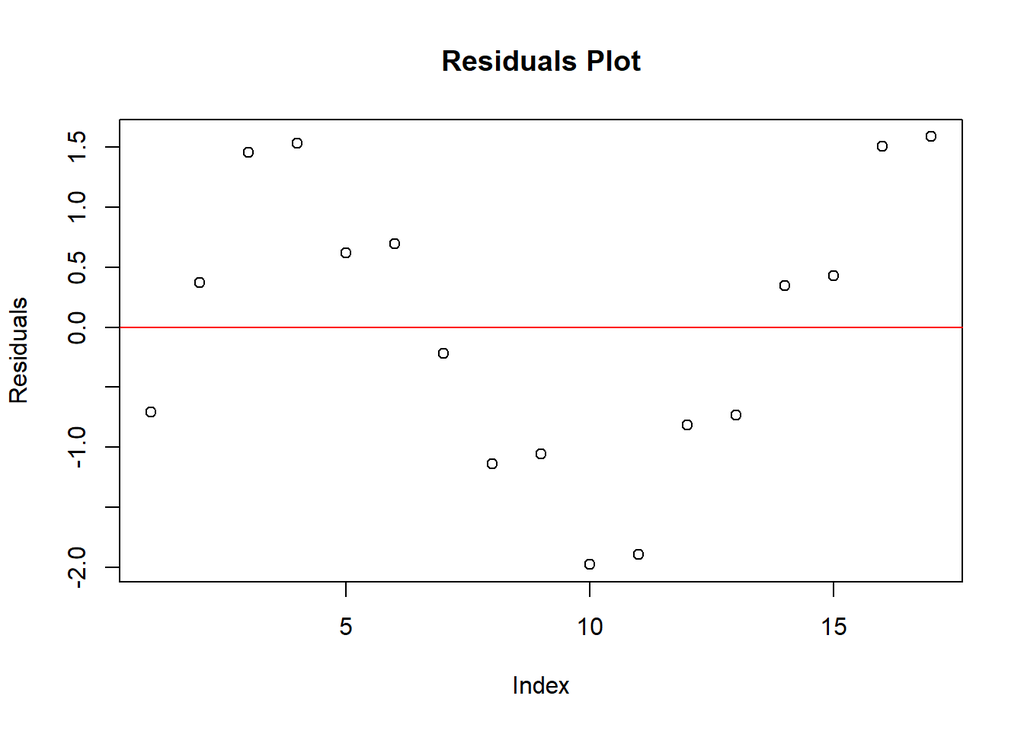

```r
# Plot residuals
plot(model$residuals, main="Residuals Plot", xlab="Index", ylab="Residuals")
abline(h = 0, col = "red")
```

```r
# Residual summary
summary(model$residuals)
```

```
##    Min. 1st Qu.  Median    Mean 3rd Qu.    Max.
## -1.9779 -0.8162  0.3456  0.0000  0.6985  1.5882
```

## Problem using data set FEV.DAT

1. Do data exploration (e.g., sample mean/variance, histogram, etc).

```r
# Load the data
data <- read.csv("FEV.DAT.csv", header = TRUE)

# Data Exploration
# Calculate sample means and variances
sample_means <- colMeans(data[, -c(1, 2)], na.rm = TRUE)
sample_variances <- apply(data[, -c(1, 2)], 2, var, na.rm = TRUE)

mean_df <- data.frame(Variable = names(sample_means), Mean = sample_means)
variance_df <- data.frame(Variable = names(sample_variances), Variance = sample_variances)
```

Sample Means:

```r
print(mean_df)
```

```
##       Variable        Mean
## Age        Age  9.93119266
## fev        fev  2.63677982
## Hgt        Hgt 61.14357798
## Sex        Sex  0.51376147
## Smoke    Smoke  0.09938838
```

Sample Variances:

```r
print(variance_df)
```

```
##       Variable   Variance
## Age        Age  8.7257330
## fev        fev  0.7517915
## Hgt        Hgt 32.5300582
## Sex        Sex  0.2501932
## Smoke    Smoke  0.0896474
```

Histograms:

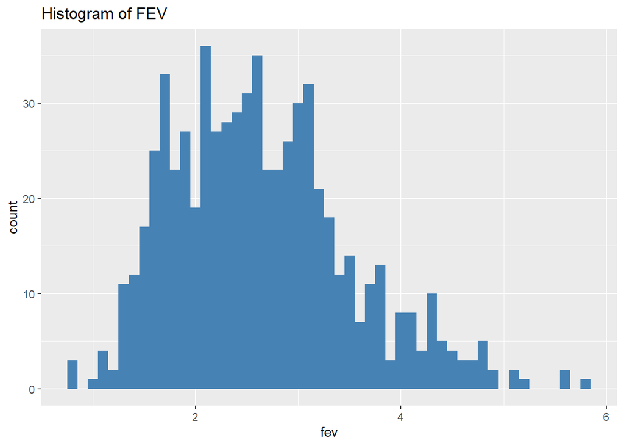

```r
ggplot(data, aes(x = fev)) + geom_histogram(binwidth = 0.1, fill = "steelblue") + ggtitle("Histogram of FEV")
```

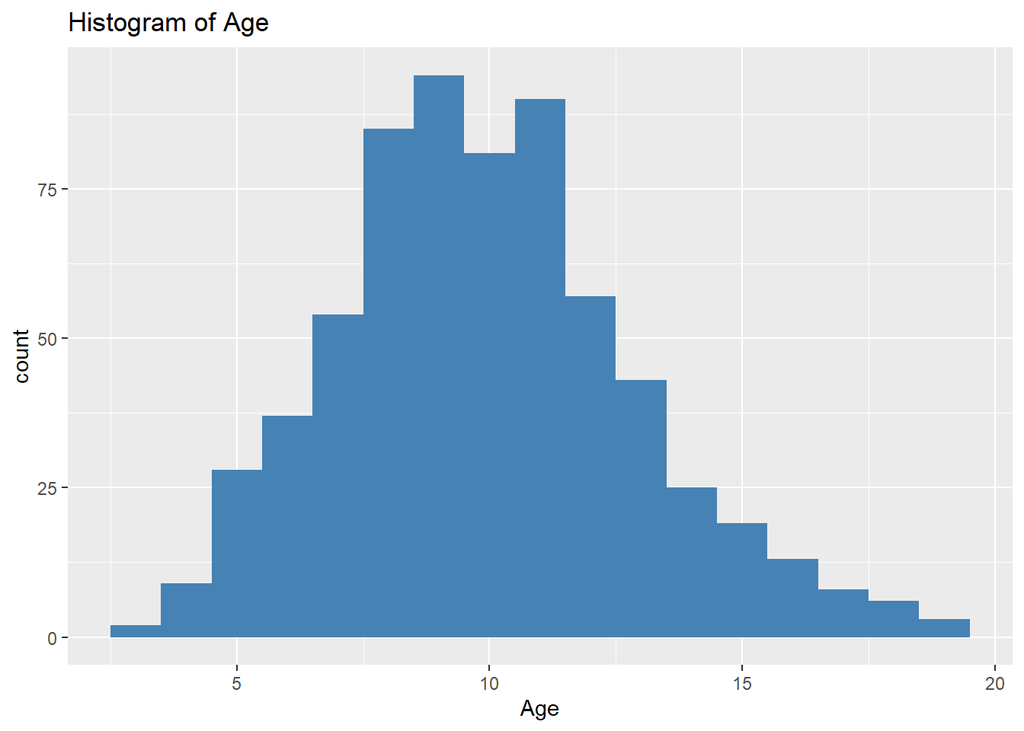

```r
ggplot(data, aes(x = Age)) + geom_histogram(binwidth = 1, fill = "steelblue") + ggtitle("Histogram of Age")
```

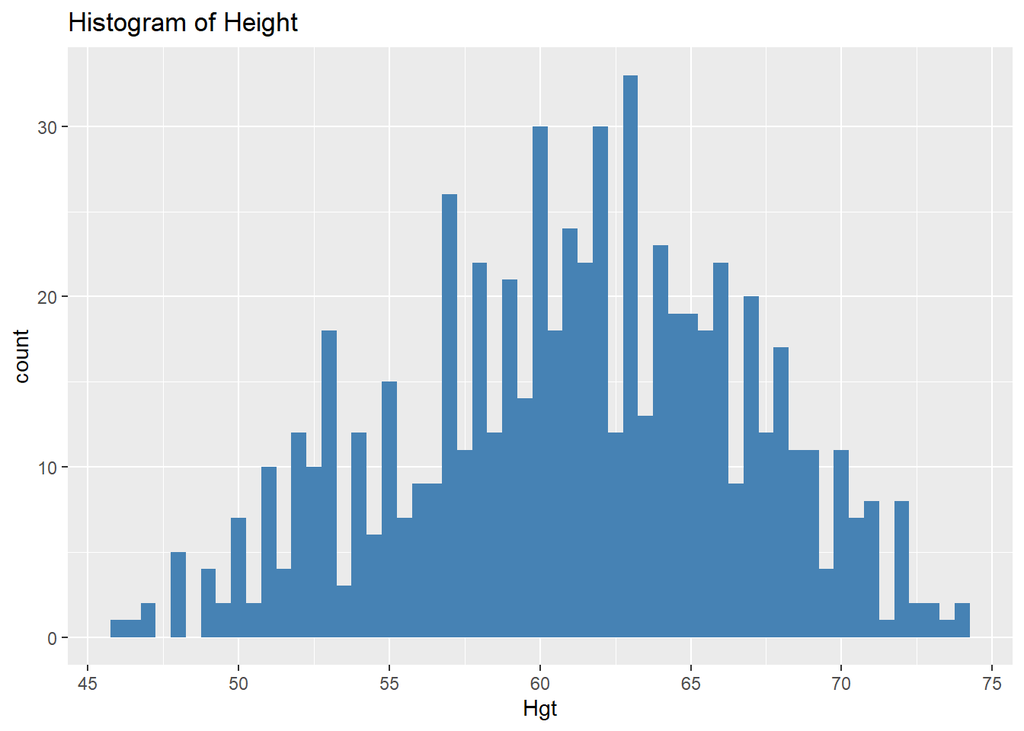

```r
ggplot(data, aes(x = Hgt)) + geom_histogram(binwidth = 0.5, fill = "steelblue") + ggtitle("Histogram of Height")
```

For ‘Sex’ and ‘Smoke’, they are 0/1 binary variables, and we can simply calculate the proportion of each category.

```r
# Proportion
sex_proportion <- table(data$Sex) / nrow(data)
smoke_proportion <- table(data$Smoke) / nrow(data)
sex_proportion_df <- data.frame(Sex = names(sex_proportion), Proportion = as.vector(sex_proportion))
smoke_proportion_df <- data.frame(Smoke = names(smoke_proportion), Proportion = as.vector(smoke_proportion))

print(sex_proportion_df)
```

```
##   Sex Proportion
## 1   0  0.4862385
## 2   1  0.5137615
```

```r
print(smoke_proportion_df)
```

```
##   Smoke Proportion
## 1     0 0.90061162
## 2     1 0.09938838
```

2. Use regression methods to examine the relationship between level of pulmonary function (the outcome, “fev”) and other factors (e.g., age, height, and personal smoking) considered separately and simultaneously.

(2.1) Provide a summary of the analyses. Write a few sentences that 1) describe the statistical methods used and 2) the results of the analysis as you might report in a research publication.

```r
# Regression Analysis
# Univariate models
model_age <- lm(fev ~ Age, data = data)
model_hgt <- lm(fev ~ Hgt, data = data)
model_smoke <- lm(fev ~ Smoke, data = data)
model_sex <- lm(fev ~ Sex, data = data)

# Multivariate model
model_multivariate <- lm(fev ~ Age + Hgt + Smoke + Sex, data = data)
```

```r
cat("Univariate Model: Age")
```

```
## Univariate Model: Age
```

```r
summary(model_age)
```

```
##
## Call:
## lm(formula = fev ~ Age, data = data)
##
## Residuals:
##      Min       1Q   Median       3Q      Max
## -1.57539 -0.34567 -0.04989  0.32124  2.12786
##
## Coefficients:
##             Estimate Std. Error t value Pr(>|t|)
## (Intercept) 0.431648   0.077895   5.541 4.36e-08 ***
## Age         0.222041   0.007518  29.533  < 2e-16 ***
## ---
## Signif. codes:  0 '***' 0.001 '**' 0.01 '*' 0.05 '.' 0.1 ' ' 1
##
## Residual standard error: 0.5675 on 652 degrees of freedom
## Multiple R-squared:  0.5722, Adjusted R-squared:  0.5716
## F-statistic: 872.2 on 1 and 652 DF,  p-value: < 2.2e-16
```

A simple linear regression analysis was performed to investigate the relationship between FEV and age. The summary of the model shows that age is a significant predictor of FEV. Specifically, for each additional year of age, the FEV is expected to increase by 0.222 liters (p < 0.001). The model explained approximately 57.2% of the variance in FEV, as indicated by the R-squared value. The results suggest a strong positive relationship between age and pulmonary function within the studied population.

```r
cat("Univariate Model: Height")
```

```
## Univariate Model: Height
```

```r
summary(model_hgt)
```

```
##
## Call:
## lm(formula = fev ~ Hgt, data = data)
##
## Residuals:
##      Min       1Q   Median       3Q      Max
## -1.75167 -0.26619 -0.00401  0.24474  2.11936
##
## Coefficients:
##              Estimate Std. Error t value Pr(>|t|)
## (Intercept) -5.432679   0.181460  -29.94   <2e-16 ***
## Hgt          0.131976   0.002955   44.66   <2e-16 ***
## ---
## Signif. codes:  0 '***' 0.001 '**' 0.01 '*' 0.05 '.' 0.1 ' ' 1
##
## Residual standard error: 0.4307 on 652 degrees of freedom
## Multiple R-squared:  0.7537, Adjusted R-squared:  0.7533
## F-statistic:  1995 on 1 and 652 DF,  p-value: < 2.2e-16
```

```r
cat("Univariate Model: Smoke")
```

```
## Univariate Model: Smoke
```

```r
summary(model_smoke)
```

```
##
## Call:
## lm(formula = fev ~ Smoke, data = data)
##
## Residuals:
##     Min      1Q  Median      3Q     Max
## -1.7751 -0.6339 -0.1021  0.4804  3.2269
##
## Coefficients:
##             Estimate Std. Error t value Pr(>|t|)
## (Intercept)  2.56614    0.03466  74.037  < 2e-16 ***
## Smoke        0.71072    0.10994   6.464 1.99e-10 ***
## ---
## Signif. codes:  0 '***' 0.001 '**' 0.01 '*' 0.05 '.' 0.1 ' ' 1
##
## Residual standard error: 0.8412 on 652 degrees of freedom
## Multiple R-squared:  0.06023,    Adjusted R-squared:  0.05879
## F-statistic: 41.79 on 1 and 652 DF,  p-value: 1.993e-10
```

This simple linear regression analysis was performed to explore the relationship between FEV and personal smoking status. It indicates that smoking status is also a significant predictor of FEV. Specifically, smokers have an average FEV that is 0.711 liters higher than non-smokers (p < 0.001). However, the model explains only about 6.02% of the variance in FEV. While smoking status does have a statistically significant effect on pulmonary function, it is a relatively weak predictor compared to age and height.

```r
cat("Univariate Model: Sex")
```

```
## Univariate Model: Sex
```

```r
summary(model_smoke)
```

[output not shown]

```r
cat("Multivariate Model")
```

```
## Multivariate Model
```

```r
summary(model_multivariate)
```

```
##
## Call:
## lm(formula = fev ~ Age + Hgt + Smoke + Sex, data = data)
##
## Residuals:
##      Min       1Q   Median       3Q      Max
## -1.37656 -0.25033  0.00894  0.25588  1.92047
##
## Coefficients:
##              Estimate Std. Error t value Pr(>|t|)
## (Intercept) -4.456974   0.222839 -20.001  < 2e-16 ***
## Age          0.065509   0.009489   6.904 1.21e-11 ***
## Hgt          0.104199   0.004758  21.901  < 2e-16 ***
## Smoke       -0.087246   0.059254  -1.472    0.141
## Sex          0.157103   0.033207   4.731 2.74e-06 ***
## ---
## Signif. codes:  0 '***' 0.001 '**' 0.01 '*' 0.05 '.' 0.1 ' ' 1
##
## Residual standard error: 0.4122 on 649 degrees of freedom
## Multiple R-squared:  0.7754, Adjusted R-squared:  0.774
## F-statistic:   560 on 4 and 649 DF,  p-value: < 2.2e-16
```

Finally, we consider all the factors (age, height, smoking and sex) simultaneously in a multivariate linear regression model. The multivariate regression analysis revealed the following:

(2.2) Assess the goodness-of-fit of the multivariate model. Discuss your results.

```r
# Goodness-of-Fit
anova(model_multivariate)
```

```
## Analysis of Variance Table
##
## Response: fev
##            Df  Sum Sq Mean Sq   F value    Pr(>F)
## Age         1 280.919 280.919 1653.2215 < 2.2e-16 ***
## Hgt         1  95.326  95.326  560.9964 < 2.2e-16 ***
## Smoke       1   0.592   0.592    3.4843    0.0624 .
## Sex         1   3.803   3.803   22.3825 2.743e-06 ***
## Residuals 649 110.280   0.170
## ---
## Signif. codes:  0 '***' 0.001 '**' 0.01 '*' 0.05 '.' 0.1 ' ' 1
```

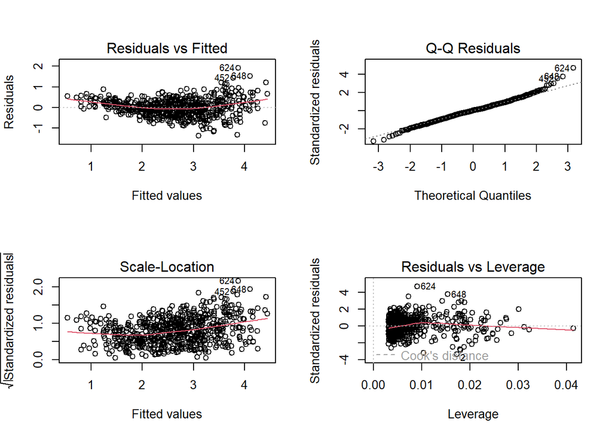

```r
par(mfrow = c(2, 2))
plot(model_multivariate)
```